# Graph Neural Network prediction of soft matter system properties: a computational essay

Rowan Orlijan-Rhyne<sup>1</sup> PHYS 094 May 2025

Mentors and collaborators: Amy Graves<sup>1</sup>, Siddhant Ranka<sup>1</sup>, Dane Morgan<sup>2</sup>, Ajay Annamareddy<sup>2</sup>, Katharina Vollmayr-Lee<sup>3</sup>

<sup>1</sup> Swarthmore College <sup>2</sup> University of Wisconson <sup>3</sup> Bucknell University

## Introduction

Hello!

*Given the interactive nature of a computational essay, this report adopts a somewhat informal tone.*

I hope you enjoy it, and if you have any questions or comments, please reach out to me at this email address!

If you have not already done so, please familiarize yourself with the file structure of this essay and the guidelines for running the code! All of this information is found in the README.

```python
# Import the dependencies
import numpy as np
import matplotlib.pyplot as plt
import matplotlib.cm as cm

# ML Intro
from sklearn.model_selection import train_test_split
from sklearn.ensemble import RandomForestRegressor
from sklearn.linear_model import LinearRegression
from sklearn.neural_network import MLPRegressor
from sklearn.metrics import mean_squared_error
import time

# GNN
import numpy as np
import matplotlib.pyplot as plt
import torch
import random
import os
import shutil
from torch_geometric.data import Data
from torch_geometric.loader import DataLoader
import torch.nn as nn
import torch.nn.functional as F
import torch.optim as optim
from random import shuffle
from torch_scatter import scatter_add
from torch.optim.lr_scheduler import ExponentialLR, MultiStepLR, ReduceLROnPlateau

# visualization
import networkx as nx
from torch_geometric.utils import to_networkx
import re
import cv2
from IPython.display import Video
```

```python
import sys
from pathlib import Path

# Automatically add the parent of 'gnn_versions' to sys.path
module_dir = Path(__file__).resolve().parent if '__file__' in globals() else Path().resolve()
package_root = module_dir / "gnn_versions"

if not package_root.exists():
    raise FileNotFoundError("Could not locate the 'gnn_versions' directory.")

sys.path.append(str(module_dir))
```

### Have some fun learning about ML

Machine learning (ML) is a field of artificial intelligence focused on producing models that can learn from data, identify patterns, and make decisions with minimal human supervision. Rather than being explicitly programmed to perform a task, a machine learning model improves its performance by training on data.

The following is an example meant to introduce you to the general methodology and terms involved in ML:

Explore the ML Playground ➡️

### Jamming and soft matter

Now let's turn to the physical systems and the data we'd like to study: 2-dimensional simulations of sheared bidisperse systems.

That probably sounds like gibberish, so we'll break it down:

Soft matter can be in solid, liquid, or gas phases, and we work with jammed systems of grains which are in the solid phase. Here, when we say "solid," we mean *disordered solid* (think beach sand). These systems are rigid and elastic, and the particles or grains of which they are comprised are densely packed. The phase transition from unjammed to jammed occurs at a critical density of particles described by the packing fraction

$\phi = n v_{1}$ where $n$ is the number density and $v_{1}$ is the volume of a single particle,

so that the packing fraction is the space occupied by particles as a fraction of the total space. In 2 dimensions, the critical packing fraction $\phi_{c} = 0.84$ at zero stress and temperature.

We can also apply a force to these systems which we refer to as a shear stress:

$\sigma = \frac{F}{A}$

In response to this shear stress, the system experiences a relative displacement, the strain:

$\epsilon = \frac{\Delta x}{L_{y}}$ where $L_{y}$ is the vertical dimension of the system.

For jammed grains the two are related with $G$, the shear modulus:

$\sigma = G \epsilon$

### LAMMPS: Large-scale atomic/molecular massively parallel simulator

LAMMPS is a piece of software developed by Sandia National Lab which we use to simulate 2-dimensional hard spheres in a microcanonical or NVE (i.e., fixed energy, fixed number of particles) ensemble. The simulation is athermal and isochoric.

For our simulation, then, the packing fraction is

$\phi = (n_{A} \pi R_{A}^{2} + n_{B} \pi R_{B}^{2}) / L^{2}$

Below is an illustration of the minimization period of the simulation, courtesy of Akm S. Mahmud (Bucknell University).

[figure not shown]

The system is then sheared, meaning the top and bottom walls move at a constant velocity and are unaffected by the forces of their contacts. The walls move at a shear rate of $\dot{\gamma} = 7.5 * 10^{-5}$, and this speed is slow enough so that the process is quasistatic. After the system is "healed," particles within three big particle diameters of the edges of the box are assigned to be wall particles.

Below is an illustration of the bidisperse sheared system. Pins (small fixed particles with radius 0.004) are pictured in bright green, but this report will not study systems with pins. Instead, see work from Amy Graves on predicting the distance of a particle from the nearest pin with graph neural networks. Wall particles are colored yellow, while system particles are blue and red. The wall speed $v$ is calculated using the shear rate $\dot{\gamma}$ as shown.

For further information about LAMMPS and its uses please see [Vollmayr-Lee 2020](https://www.eg.bucknell.edu/~kvollmay/AJP88_401_2020.pdf).

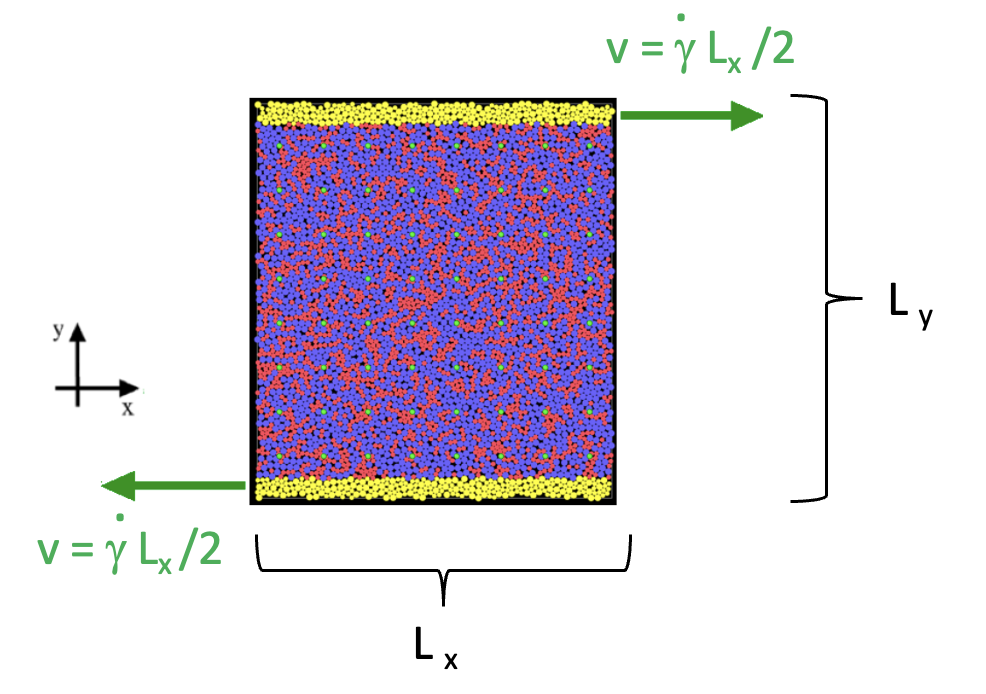

### ML and soft matter systems: a nod to the literature

[Cubuk et al. (2015)](https://doi.org/10.1103/PhysRevLett.114.108001)

- Support Vector Machines (SVMs) used on jammed and glassy solids to predict particle rearrangements and identify flow defects
- Trained SVMs on local structural descriptors to identify "soft spots" or regions more prone to rearrangement. These soft spots were more predictive than traditional measures, providing insight into plastic deformation in amorphous solids.

[Baity-Jesi et al. (2018)](https://doi.org/10.48550/arXiv.1803.06969)

- Identified parallels between glassy physics and neural network optimization for deep neural networks (DNNs). Over-parameterized networks show slow relaxation akin to aging in glasses, while under-parameterized networks are more prone to being trapped in local minima.

[Bapst et al. (2020)](https://doi.org/10.1038/s41567-020-0842-8) ([Supplementary Info](https://static-content.springer.com/esm/art%3A10.1038%2Fs41567-020-0842-8/MediaObjects/41567_2020_842_MOESM1_ESM.pdf))

- Graph Neural Networks (GNNs) used on glass-forming systems to predict long-time dynamics from initial structure.
- GNNs accurately predicted dynamical heterogeneities and future rearrangements from static particle configurations, outperforming traditional methods and highlighting structure-dynamics correlations in glasses.

[Wang & Zhang (2021)](https://doi.org/10.1038/s41467-021-25490-x)

- Graph Neural Networks (GNNs) and Swap Monte Carlo used to predict the plastic resistance and structural stability of Cu-Zr metallic glasses.
- Found system states that are geometrically ultra-stable yet energetically metastable, drawing a distinction between mechanical robustness and energy minimization.

[Mandal & Sollich (2022)](https://doi.org/10.1038/s41467-022-31732-3) ([Supplementary Info](https://static-content.springer.com/esm/art%3A10.1038%2Fs41467-022-31732-3/MediaObjects/41467_2022_31732_MOESM1_ESM.pdf))

- Graph Neural Networks (GNNs) used to predict force network structure in jammed solids under various system characteristics.
- The authors find success for various parameters and show that the model can perform well on systems which differ from its training data.

[Ridout & Liu (2024)](https://arxiv.org/abs/2406.05868)

- Used support vector machine (SVM) to learn softness parameter.
- Developed a model where particle rearrangement probability is governed by a learned "softness" metric. The model studies facilitation, or when single particle rearrangements affect the susceptibility of other particles to undergo displacements.

### GNNs: What are they, and why did we choose one?

You'll notice upon glancing at the "nod to the literature" above that some studies use support vector machines (SVMs) to study softness. More specifically, SVMs draw a hyperplane in the feature space to classify particles as being more or less susceptible to displacements, or with a higher/lower $D^{2}_{min}$ value. Other studies, however, use graph neural networks (GNNs) to study properties of jammed systems. This [gloss](https://deepmind.google/discover/blog/towards-understanding-glasses-with-graph-neural-networks/) of [Bapst et al. (2020)](https://doi.org/10.1038/s41567-020-0842-8) provides a good introduction to the subtleties and the advantages of using a GNN to study soft matter systems. This [paper](https://distill.pub/2021/gnn-intro/) provides insight into the architecture of GNNs.

In essence, we leverage Pytorch to create a graph representation of particles from a soft matter snapshot (or more than one), and the model performs transformations of the graph so that it can predict a per-particle property of our choosing. The creation of the graph designates each particle a 'node' with position information, and 'edges' are drawn between particles within a certain distance of each other so that the model can reliably capture their interactions. As you may know or soon learn, GNNs involve many different parameters/hyperparameters and can be modified with a variety of bells and whistles.

The weights and biases which govern the graph's transformations are updated via a process of 'training' in which a chosen loss function (e.g. RMSE, Huber Loss, binary cross entropy) describes the model's performance over time. As the weights and biases are optimized, the model explores the peaks and (ideally) valleys of the loss as a function of the model parameters. The way in which the model searches for minimum(s) of the loss function is governed largely by (i) the optimizer (determines the update vector of the weights, often computed using the gradient of the loss) and (ii) the learning rate (determines the amount by which the weights are displaced by the update vector).

To dive deeper into the way in which the weights are updated, we talk about a process called backpropagation, a method for computing gradients of a loss function with respect to the network's parameters.

In a GNN, each node starts with an initial feature vector which is then updated layer by layer through message passing, where each node aggregates information from its neighbors and combines it with its own features. This process propagates information across the graph, allowing each node to build a representation that reflects its local structure and context.

Each layer applies a linear transformation to the aggregated features, followed by a non-linear function called an activation function. We use the Rectified Linear Unit (ReLU) function, defined as:

$ \mathrm{ReLU}(x) = \max(0, x) $

The activation function introduces non-linearity into the model, allowing it to learn more complex patterns that a purely linear model could not capture. Once the final node representations are computed (after several layers), the model makes predictions and computes the loss. Backpropagation then computes how the model’s weights contributed to the loss, and the optimizer uses these gradients to update the weights in a direction that reduces the loss. This cycle of message passing, transformation, activation, loss computation, and weight update continues throughout training.

## Nearest Neighbors: a 'toy' problem

Nearest Neighbors Problem ➡️

## Predicting x-displacements at multiple MD timesteps

We now turn to a more interesting task: predicting x-displacements in the system based on position information for the particles at a prior time step.

Although it will be easier to train a model to predict displacements at short time steps, you can imagine the power of an algorithm to predict displacements at long time steps: In essence, if the model can extrapolate to different system conditions, it would replace a deterministic, computationally heavy software package like LAMMPS.

### Displacement in a system of sheared grains

Get a feel for x-displacement ➡️

### Refinements to the GNN

To accomplish this task of finding the x-displacements for particles, let's introduce a little sophistication to our model.

#### Learning rate schedulers

Up until now, we've started with a learning rate which has remained constant across all epochs of training.

However, it is advantageous to introduce a time-varying learning rate in the form of what we call a scheduler. This allows us to explore the loss landscape early in training and zero in on a favorable minimum over time. Convergence is quickened by a learning rate that can be large enough to efficiently minimize the loss early on, and later, convergence is ensured as the learning rate is lessened so that we don't jump out of a minimum. Instead, we explore its subtleties, and in an ideal world, this allows us to chart a fine-grained route toward optimization.

There are many different learning rate schedulers to choose from, and PyTorch gives a great overview at this [link](https://docs.pytorch.org/docs/stable/optim.html#how-to-adjust-learning-rate).

- No scheduler
- Exponential scheduler, multistep scheduler, and reduce learning rate on plateau scheduler
- The same as previous model but with different hyperparameters
- Cosine annealing scheduler and reduce learning rate on plateau scheduler

The exponential scheduler decays the learning rate at each epoch by a fixed factor gamma;

MultiStep decays the learning rate by another multiplicative factor but only at certain user-specified 'milestone' epochs (e.g. epochs 100, 250, 400);

ReduceLROnPlateau scheduler bumps the learning rate down by another particular factor if the validation loss sees no improvement over a certain number of epochs (e.g. 5);

and the cosine annealer cycles the learning rate between a maximum and minimum value over the course of a certain number of epochs.

Thus, when applied simultaneously, the learning rate schedulers can work in tandem to considerably optimize the training and convergence of the model.

Below is an example of how the learning rate behaves over time for a cosine annealing learning rate combined with reduce on plateau scheduler. Notice that the amplitude of the oscillation decreases over time due to the reduction of the learning rate on plateaus:

[figure not shown]

My results can be found in `../output_archive/neighbors` but are easily summarized by the figure below, which plots the best performance by the loss function at various points across the 500 epochs of training.

The fact that the best and worst scheduler configurations are identical but use slightly different parameters is extremely significant and indicates the importance of the hyperparameters of the schedulers themselves, not only the choice of scheduler.

We see, nonetheless, that my second try of the exponential scheduler, with multi-step scheduler, and with reduce learning rate on plateau outperforms the rest at every hundred-epoch juncture.

[figure not shown]

It should be noted, too, that these performance metrics pertain to the neighbors task, and as a result, the conclusions drawn from them may not be entirely applicable to the displacement task. Thus, we should consider revisiting this process in the future by trying different scheduler configurations as well as different hyperparameter choices for each configuration.

For the moment, I'm using the orange/yellow configuration (exponential + multi-step + reduce on plateau) for the displacement task.

After initializing the schedulers, we tell them to act at the appropriate points in the code:

- The multi-step and exponential schedulers are called at the end of each epoch of training.
- And the reduce on plateau scheduler is called only if the model is in the validation phase, at which point we pass it the loss.

#### Exponential Moving Average (EMA)

The EMA is a slightly more involved addition to the model architecture as it requires the declaration of a class in the model.

At its core, EMA is meant to maintain a smooth, historical version of the weights and biases. Instead of only relying on the latest, potentially noisy parameters to generate predictions at each epoch, EMA computes a running average of the weights where recent updates are usually prioritized. This decreases the frequency and amplitude of fluctuations in parameters/loss across epochs, stabilizing training. It also has been [found](https://doi.org/10.48550/arXiv.2411.18704) to produce models which generalize predictions better across different contexts.

```python
class EMA:
    def __init__(self, model, decay):
        self.model = model
        self.decay = decay
        self.shadow = {}
        self.backup = {}

    def register(self):
        for name, param in self.model.named_parameters():
            if param.requires_grad:
                self.shadow[name] = param.data.clone()

    def update(self):
        for name, param in self.model.named_parameters():
            if param.requires_grad:
                assert name in self.shadow
                new_average = (1.0 - self.decay) * param.data + self.decay * self.shadow[name]
                self.shadow[name] = new_average.clone()

    def apply_shadow(self):
        for name, param in self.model.named_parameters():
            if param.requires_grad:
                assert name in self.shadow
                self.backup[name] = param.data
                param.data = self.shadow[name]

    def restore(self):
        for name, param in self.model.named_parameters():
            if param.requires_grad and name in self.backup:
                param.data = self.backup[name]
        self.backup = {}
```

In the training loop, EMA is computed based on the training update vector and is subsequently applied to parameters governing the validation predictions.

#### Early stopping and choosing the best epoch

Although we'd like to run our model for hundreds and hundreds of epochs every time, we don't always have that kind of time and compute power, and besides, sometimes it diverges! So, to better identify when the model diverges and is not worth pursuing, we can implement 'early stopping.' This simply stops the training when the loss does not improve over the course of a certain number of epochs. Sometimes, during training, the loss can increase briefly before decreasing again, but if it shows no sign of decreasing after a period of worsening performance, we want to pull the plug. We can choose different thresholds for stopping tolerance, and I use 50 epochs here.

The implementation of early stopping consists mainly of a simple addition to the $\texttt{check\_accuracy}$ function: here is the pseudocode.

```
count epochs since best RMSE
if validation:
    if RMSE better than previous best:
        save the model
        reset the counter
        record this epoch as best one
        return: best_epoch, counter, new best RMSE
    else:
        update epoch counter
        return best_epoch, counter, best RMSE
```

Notice here that it also becomes useful to keep track of the epoch at which we record the lowest RMSE so that we can save the model state here and so that we can keep track of the model's global performance across training.

#### Standardization of targets and predictions

Although it is generally good practice to standardize the data to a mean of 0 and standard deviation of 1, this step is particularly important for our task. This is because the magnitude of the x-displacements, especially at smaller time steps, is quite small. If the target is too small, we can run into the issue of vanishing/exploding gradients of the loss function or that of floating point error. This causes instability during training and/or divergence.

So, to standardize the data, we must subtract by the mean and divide by the standard deviation:

$ y_{std} = \frac{y_{old} - \mu}{\sigma} $

But the standard deviation and mean of what data? (You may ask!)

We use, in fact, the training data as a basis for standardization. In other words, we standardize both the training and validation data by the training mean and standard deviation so as not to implicitly 'teach' the model anything about the validation set. The StackExchange discussion [here](https://stats.stackexchange.com/questions/495357/why-do-we-normalize-test-data-on-the-parameters-of-the-training-data) gives a more extensive explanation of this.

```python
# In practice, we must standardize the data as we load it in before the training loop:
from gnn_versions.customDataset import CustDataset
cache_directory = 'cached_data'
root_dir = 'graph_inputdata/MD50000'
dataset = CustDataset(h=5, root_dir=root_dir)
data_loader = DataLoader(dataset=dataset, batch_size=1, shuffle=True)
if os.path.exists(cache_directory): shutil.rmtree(cache_directory)
os.makedirs(cache_directory, exist_ok=True)

# initialize array to store values for calculating mean, std
train_targets = []

for i, (data, targets) in enumerate(data_loader):
    torch.save((data,targets), os.path.join(cache_directory, f'data_{i}.pt'))
    mask = np.array(data.train_mask).reshape(-1)
    train_targets.append(targets[0][mask])  # assuming batch_size=1 and targets.shape = (1, num_nodes)

# calculate mean, std of targets
train_targets_tensor = torch.cat(train_targets)
target_mean = train_targets_tensor.mean()
target_std = train_targets_tensor.std()

print(f"(training) target mean: {target_mean.item()}, std: {target_std.item()}")
```

```
training particles: 4100
validation particles: 456
(training) target mean: 0.0019972347654402256, std: 0.024793803691864014
```

And we also must add code in the $\texttt{check\_accuracy()}$ function to ensure that both the training and validation targets are standardized in the same manner.

#### Learning rates

Again, you can find all of my results and figures in `../output/archive`:

- For displacement between MD 0 and 10 000, I found through performing multiple 500-epoch runs for various initial learning rates that the best learning rate was somewhere between $10^{-5}$ and $2.5 * 10^{-5}$ (trials numbered 5 and 7 in this folder: `../output_archive/displacement_MD10000/normalized`)).
- For displacement between MD 0 and 50 000, I did 3 independent runs with the initial learning rate of $10^{-5}$ and obtained best RMSEs slightly larger than the MD 10 000 case. The results for this sequence of tests can be found at `../output_archive/displacement_MD50000`.

In both cases, rich text files called 'params' describe the choices of parameters (i.e. learning rate, message passing layers, etc) for each run.

This figure illustrates the RMSE on a log-log scale across 500 epochs of training for the first trial of $10^{-5}$ initial learning rate on the MD 10 000 displacement task.

[figure not shown]

However, our University of Wisconsin collaborators suggested that this may have been too small of a learning rate. As a result, we now choose $10^{-4}$ for most displacement tasks, and this has proven to be a worthy suggestion.

#### Dropout

`nn.Dropout()` is a technique used to prevent overfitting during training. It randomly chooses a fraction of the elements in the input tensor (only during training) to set to zero. This forces the network to not rely too heavily on any particular node or feature, since a random portion of them are pruned at each forward pass. This helps the model generalize better by making it robust to missing or noisy features.

In practice, it is applied in the model after each activation function call on a fully-connected layer.

Here's a demo of dropout in action:

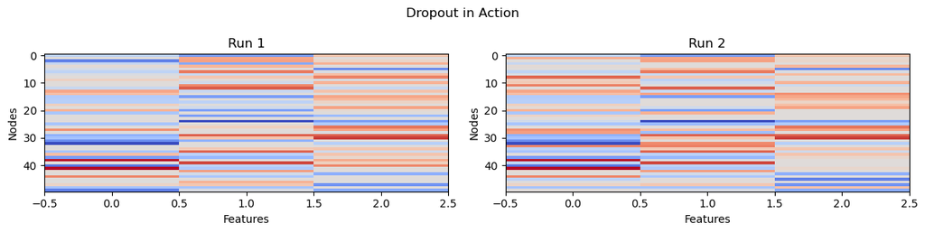

```python
# Simulate a fully connected layer (50 nodes, 3 features)
features = torch.randn(50, 3)

# Dropout layer with p=0.25
dropout = nn.Dropout(p=0.25)
dropout.train()

# Run it twice to see randomness
fig, axs = plt.subplots(1, 2, figsize=(12, 3))
for i in range(2):
    dropped = dropout(features)
    axs[i].imshow(dropped.detach().numpy(), cmap='coolwarm', aspect='auto')
    axs[i].set_title(f"Run {i+1}")
    axs[i].set_xlabel("Features")
    axs[i].set_ylabel("Nodes")

plt.suptitle("Dropout in Action")
plt.tight_layout()
plt.show()
```

I tested dropout for use in our model by running 0.0, 0.1, and 0.25 percent dropout on the x-displacement task for 50 000 MD steps from the initial configuration, and I ran the model twice for each choice of dropout fraction.

Below, aggregated validation and training RMSEs between the two independent runs are plotted on a log-log scale, with the best validation RMSEs highlighted.

Although the aggregated 0.25 dropout fraction RMSE over the two runs is worse than the aggregated 0.0 and 0.1 dropout RMSEs, the best RMSE obtained by one of the trials with 0.25 dropout fraction is better than the best RMSE from the other choices. Our University of Wisconsin collaborators suggested that this is to be expected, and we should choose 0.25 dropout.

I also tested bigger dropout fractions, but these models diverged every time.

The result of these runs and the parameters which were used are found in the same directory as the below plot: `output_archive/displacement_dt=50000_dropout`.

[figure not shown]

#### Parameter choices, model restarts, and setting the device

As we've used the GNN code to train and test more and more models, a few aspects of the most recent code versions are important to remark on, since they allow for smooth training, restarts, and workflows.

First, a file is written with parameter choices and information about the runs, including time, version used, and more. It looks like this:

[output not shown]

Second, one can stop and restart training of a model quite easily from a savedmodel.pkl (saved at each epoch) or bestmodel.pkl (saved if validation RMSE is better than previous best) file, which records plenty of information about the model. When a restart is done, actual and predicted values, learning rates, and more are appended to previous output files, and the exponential moving average is saved, so that weights and biases are picked up to ensure smooth training.

The code to save the model state looks like this:

```
torch.save({
            'model_state_dict': model.state_dict(),
            'optimizer_state_dict': optimizer.state_dict(),
            'lr': optimizer.param_groups[0]['lr'],
            'epoch': epoch,
            'rmse': rmse,
            'ema_state': ema.shadow,
            'scheduler1_state': scheduler1.state_dict(),
            'scheduler2_state': scheduler2.state_dict(),
            'scheduler_plateau_state': scheduler_plateau.state_dict(),
            'best_epoch': best_epoch,
            'improvement_counter': stopping_count},
        os.path.join(output_dir, 'savedmodel.pkl'))
```

Another development is that we can choose between local CPU, local GPU, or remote GPU(s). If you have a Mac with GPU, be sure that this is the processor on which the code is being run, given that it considerably accelerates training compared to local CPU. However, if you're planning on doing quite a few runs, I hope, for your sake, that you've got access to a supercomputer!

#### Message passing layers, edge thresholds

A large portion of the testing you will observe in the ouput_archive folder is done on MD 50 000 X displacements with initial time MD 0. The most involved testing during summer 2025 was on the choices of message passing layers and of edge thresholds, all with a learning rate of $10^{-4}$.

Message passing layers are the building blocks of GNNs. In each layer, a node updates its feature vector by aggregating all the messages from its neighboring nodes and edges. This allows the network to capture relational structure and dependencies in the graph.

The number of message passing layers determines how far information can propagate through the graph. With more layers, a node can incorporate information from nodes that are further away (more hops). However, too many layers can lead to problems like over-smoothing (where node features become too similar) or vanishing gradients, while too few layers might not capture enough context. Thus, choosing the right number of message passing layers is crucial for balancing local and global information in the graph.

The edge threshold in our GNN determines the maximum distance within which an edge is drawn between two particles. In other words, if two particles are closer than the edge threshold, they are connected by an edge in the graph.

A larger edge threshold creates a denser graph, allowing each node to receive information from more neighbors. This can help the model capture more global or long-range interactions, which may be important in physical systems. However, increasing the edge threshold also increases computational cost and may introduce noise from distant, less relevant neighbors. A smaller edge threshold results in a sparser, more localized graph, potentially focusing on finer, more immediate interactions. Choosing the right edge threshold balances local precision with global context.

Mandal and Sollich use a threshold of $2 R_{B} = 2.8$, and we have used $3.0$ and $5.0$ in the past. We have seen that this parameter is extremely powerful in tasks that predict distances (i.e. distance to nearest pin) since the region in which the model can with certainty draw connections between nodes is equal to the number of message passing layers times the edge threshold parameter. So, how would this change the model's performance in other tasks like x-displacement?

We tested message passing layer and edge threshold choices of 3, 6, 12, and 18 each, creating a grid-like table of aggregate best RMSE over two independent runs for each of the 16 pairs of parameter choices. These results can be found in `output_archive/displacement_dt=50000_param_tuning`. Denser graphs with more message passing layers took significantly longer to instantiate and train than smaller graphs, but we did see notable improvement as we approached 12 edge threshold or message passing layers for a given choice of the other parameter. After having done the trials, we noticed some runs were erratic near the end and did not converge nicely and smoothly as we would expect of a minimized loss function. These erratic trials were then discarded into a the `bad_data` subfolder. Trials that achieved their best RMSE before 100 epochs and subsequently terminated after 50 epochs of no improvement (early stopping with tol = 50) were also discarded into the same subfolder.

The resultant grid is shown below:

[figure not shown]

It has been proposed that we will use edge threshold 6, message passing layers 12, but this remains to be discussed in full.

Another conclusion from this round of tests relates to the spread between independent trials for our model. After discarding the 'bad data,' 9 trials with two independent runs remained. The following is an analysis of the spreads in best validation RMSE:

```
Spread between multiple runs (among runs which converge nicely in training):
Mean difference in standardized validation RMSE: 0.011305090867810778
Standard dev.: 0.008615553651226729
Maximum spread between trials: 0.029761476442217827
Minimum spread: 0.0009512268006801605
MAD: 0.00729974244295815
For context, the average validation RMSE across all runs is: 0.02849139180034399
```

So even among runs that don't go haywire (i.e. the runs which converge in a stable way), there is considerable spread. This reinforces the need for multiple independent trials of each run.

#### Training fraction testing

Although this was mainly explored by Siddhant, I will provide a brief narrative of our exploration of training fraction here.

We have normally trained with one configuration, 90% of which comprises the training set, and 10% of which is used for validation. However, our University of Wisconsin collaborators suggested that training with more particles would produce a more robust model. I have modified the pre processor so that one can use the same validation particles across different training fractions. In other words, `Pre_processing_displacement_same_val_set` allows you to create a Snapshot which trains on 90% and validates on 10%; a second Snapshot which trains on 45% and validates on the same 10% as the first; and a third Snapshot which selects 90% of particles from a separate initial configuration to train on. Siddhant is working with this code now to further improve it.

However, in a nutshell, I believe the results have suggested that a higher training fraction allows for a more robust model, such that training with two configurations produces a better model than a single configuration, which in turn outperforms training on only 45% of particles.

### X-displacement playground

The most up-to-date GNN codes are `gnn_interactive_dropout.py` and `gnn_noninteractive_dropout.py`. I've modified these slightly so that we can run the GNN to predict X displacement from this Jupyter notebook. Please take a look at the code if you'd like! If you'd rather not, we'll still just import the whole rigamarole from the file:

```python
from gnn_versions.gnn_interactive_foripynb import main
```

```python
MP_layers = 10
edge_threshold = 5
p = 0.25
timesteps = ['5000_inf', '50000_inf', '10000', '50000']

# choose the timestep which you want to focus on
print("You can choose between four snapshot files,")
print("each with 90% training fraction:")
print(" - 5000 MD steps from 41100000 (type '0')")
print(" - 50000 MD steps from 41100000 (type '1')")
print(" - 10000 MD steps from initialization (type '2'")
print(" - 50000 MD steps from initialization (type '3'")

time.sleep(1)

print("NOTE: With the equilibrium regime, the distinction between wrapped")
print("and unwrapped coordinates becomes important.")
print("This distinction is made in the pre processing code.")

fname = timesteps[int(input("Which snapshot would you like to use?"))]
```

```
You can choose between four snapshot files,
each with 90% training fraction:
 - 5000 MD steps from 41100000 (type '0')
 - 50000 MD steps from 41100000 (type '1')
 - 10000 MD steps from initialization (type '2'
 - 50000 MD steps from initialization (type '3'
NOTE: With the equilibrium regime, the distinction between wrapped
and unwrapped coordinates becomes important.
This distinction is made in the pre processing code.
```

Great, we can now go ahead and do some training!

```python
# this function essentially runs the gnn_interactive code for you right here!

# if you'd like to use a .pkl file, make sure it is in an
# output folder of the same name as the one which you input,
# located alongside this notebook


main(MP_layers, edge_threshold, fname, p)
```

[output not shown]

Feel free to use the parity plot function in the Nearest Neighbors Playground notebook to plot the output of your run.

I'd also encourage you to check out my Julia plotting code `output_archive/plots.jl` and perhaps translate it into Python so that you can generate learning rate, RMSE, log(RMSE), standardized units parity, original units parity, and single particle prediction plots on your own!

Examples of the plots produced with this code can be found in subfolders of many of the runs in the output_archive.

### Results

In parity plots, the actual and predicted values should be plotted as transparent circles. This allows us to clearly see where the bulk of the data is located. Since at 10 000 timesteps, particles have not undergone much displacement with the exception of wall particles, we see large clusters of data around $\pm 2$ standard deviations from $\mu = 0$ corresponding to the wall particles as well as a large cluster of particles which have undergone little to no displacement. At MD 50 000 timesteps, the cluster around $0$ is less concentrated since the information from the moving walls has had some time to travel toward the middle of the system.

In both training and validation parity plots for MD 10 000, you might notice a vertical line, which denotes a presence of false positives. In other words, the model is predicting displacements for particles which in reality undergo little to no displacement. I'm referring to this as the "false positive 'scare'" detailed below.

#### The false positive 'scare'

Initially, we did not plot the actual and predicted values with clear circles and could not discern the data density of different displacement values as easily. As a result, we were quite concerned about the presence of the false positive line. Nonetheless, this led to a fruitful discussion of the physics at play and the creation of some nice plots.

To better identify the source of these false positives, we wanted to understand the location of the particles that were being identified as false positives. So, we plot the actual and predicted values as a function of the epoch for certain regions of the simulation box:

[figure not shown]

Here, we're zeroing in on the particles with y-coordinates between the 5 and 7.25 percentiles at the bottom of the gridbox. The walls are defined to contain all the particles within six big particle radii of the bottom of the simulation:

$ y_{wall} = 6 * 1.4 = 8.4 $

$ L_{y} = 166.91 $

$ \mathrm{wall\_percentile} = 8.4 / 166.91 = 0.0503265 \approx 5 \%$

So selecting particles with y-coordinates in the first 2.25 percentiles above 5 percent means that we're looking at the particles closest to the bottom walls.

The light blue lines represent the predictions generated by the model for each particle, while the light dotted red lines represent the actual displacement values of each particle (constant across all epochs). If our model managed to predict the displacements of every single particle perfectly, then we would see each little blue line converge to a little dotted red line over the course of the training. However, that's not important to a GNN. We are minimizing the root *mean* squared error, and that's why you see the thick blue line (prediction mean) follow the thick dotted red line (target mean). On average, we are predicting the displacements of the particles very well. And, on average, the particles are moving leftward, at a rate of about $-2.2$ standard deviations from the mean across the whole simulation box ($0$).

You'll notice a few dotted red lines around 0, or at standardized displacement values much less than the thick red line (target mean of particles close to bottom wall). These particles are somewhat anomalous, so the model does not care too much about them. That's why you don't see thin blue lines tracking the anomalously low displacement particles' red dotted lines in the figure above. This is what causes the false positive line on our training parity plots. Below, in the heatmap of x-displacements at 50 000 timesteps, you'll see that the presence of these anomalously low-displacement particles near the walls is warranted. There are white spots on the heatmap near the walls corresponding to particles which have not moved much at all!

So, although the model does get these particles "wrong," it's not so concerning since there are so few of them. Indeed, there are so few of them that they barely show up in the validation parity plot (which constitutes only 10% of the particles).

In the end, we've only increased our confidence in the model's predictive power as a result of the false positive 'scare,' yet we've learned valuable things about the system's characteristics and gained equally valuable analysis tools.

[figure not shown]

The real goal of this research is to build a GNN capable of being trained from an initial timestep or an early simulation time, which can then predict X displacements of particles later in the simulation. In this way, the need for deterministic and computationally intensive MD simulations is avoided if we can use machine learning.

We attempted to train the model in the equilibrium regime in addition to starting from initialization, as you may have noticed above. However, training in the equilibrium regime presents an extremely difficult task because the particle velocities are not given to the model, only their positions at a given time late in the simulation, and particle velocities heavily influence displacement.

So, we first would like to test the model's capabilities starting from the initialization of the system. We expect performance to be quite good for displacements from MD0 in early times, after which we expect some sort of 'elbow' at which we might see decreased performance. The magnitude of this elbow determines for how long our model is able to predict displacements, and perhaps even models trained on smaller times and tested on longer times still within the range of the elbow could perform well. After observing the elbow starting at MD0, we would then like to turn to training beginning at later timesteps, for which we expect to see a shorter elbow.

## Future work

Although this semester and summer have allowed us to explore GNNs and their applications to soft matter systems in some detail, there is still much to be learned about GNNs and much more to tinker with. If we had unlimited time, people, and computational resources, we'd have tested parameters far more thoroughly than we did! With that said, here are a few thoughts of mine about places in which more digging might be warranted:

First, although we understand RMSE is a standard choice for a loss function which is well suited for regression tasks, we'd like to understand the nuances of other loss functions available [here](https://docs.pytorch.org/docs/stable/nn.html#loss-functions). Additionallyt, although my choice of initial learning rate, learning rate schedulers, and their hyperparameters was informed by some research and testing, I feel that a much deeper exploration of the possible scheduler combinations and hyperparameters is necessary. In the figure above comparing different scheduler configurations, the best and the worst performing configurations corresponded to the same schedulers (exponential, multi-step, and reduce on plateau) but with different hyperparameters. This indicates that there is perhaps much more room to improve or that perhaps another choice of schedulers and hyperparameters could produce a more robust model.

Another choice in the model which I am curious to explore further is the [optimizer](https://docs.pytorch.org/docs/stable/optim.html#algorithms). We use Adam, but alternatives like AdamW or Lion could be worth trying.

Personally, I'd also like to better understand certain design choices in the GNN architecture, like, for example, other options for [nonlinear activation functions](https://docs.pytorch.org/docs/stable/nn.html#non-linear-activations-weighted-sum-nonlinearity) (like LeakyReLu).

In general, I am happy with our exploration of model performance and parameters for X displacement at MD 10000 and 50000 during the semester, and for various other timesteps in the equilibrium and early regimes in the summer, with different learning rates, message passing layers, edge thresholds, dropout fractions...

Finally, we often see in the literature that there is a lot of discussion of the generalizability of a model to portions of a sample space which have not been explored in training. However, I remain unsure as to how exactly to test a trained model on what is somewhat of a different task. In other words, I'd like to explore the mechanisms and theory behind this principle.

More specifically, for our task, the most immediate extension of the model's predictive domain is to predict displacement for longer times using a model trained on shorter times. We could start from something as simple as moving from 10000 time steps to 20000, then from 20000 to 50000, and beyond, as I mention above.

Furthermore, we can introduce new variations to the task and to the system: Pins would introduce non-affine dynamics to the system, so would the model be able to adjust to this? With training on pin data? And without? And if the model can predict displacements in a system with pins, can it also predict non-affine displacements with some slight modification to the pre-processor?

Clearly, there is much more to be done with the GNN!